# Risk Factor Analysis

## Outcome Variable

**Outcome Variable:** whz

## Predictor Variables

**Intervention Variable:** exclfeed36

**Adjustment Set:**

- arm
- sex
- brthmon
- W_mage
- meducyrs
- feducyrs
- hhwealth_quart
- hfoodsec
- W_mhtcm
- W_mwtkg
- W_mbmi
- vagbrth
- W_gagebrth
- W_birthwt
- W_birthlen
- W_nrooms
- W_nchldlt5
- month
- W_parity
- impfloor
- impsan
- safeh20
- delta_W_mage
- delta_meducyrs
- delta_feducyrs
- delta_hhwealth_quart
- delta_hfoodsec
- delta_W_mhtcm
- delta_W_mwtkg
- delta_W_mbmi
- delta_vagbrth
- delta_W_gagebrth
- delta_W_birthwt
- delta_W_birthlen
- delta_W_nrooms
- delta_W_nchldlt5
- delta_month
- delta_W_parity
- delta_impfloor
- delta_impsan
- delta_safeh20

## Stratifying Variables

The analysis was stratified on these variable(s):

- agecat
- studyid
- country

## Data Summary

| agecat | studyid | country | exclfeed36 | n_cell | n | outcome_variable |
| --- | --- | --- | --- | --- | --- | --- |
| Birth | CMC-V-BCS-2002 | INDIA | 1 | 3 | 3 | whz |
| Birth | CMC-V-BCS-2002 | INDIA | 0 | 0 | 3 | whz |
| Birth | EE | PAKISTAN | 1 | 2 | 6 | whz |
| Birth | EE | PAKISTAN | 0 | 4 | 6 | whz |
| Birth | GMS-Nepal | NEPAL | 1 | 396 | 491 | whz |
| Birth | GMS-Nepal | NEPAL | 0 | 95 | 491 | whz |
| Birth | IRC | INDIA | 1 | 0 | 3 | whz |
| Birth | IRC | INDIA | 0 | 3 | 3 | whz |
| Birth | JiVitA-3 | BANGLADESH | 1 | 6736 | 8619 | whz |
| Birth | JiVitA-3 | BANGLADESH | 0 | 1883 | 8619 | whz |
| Birth | JiVitA-4 | BANGLADESH | 1 | 1711 | 2128 | whz |
| Birth | JiVitA-4 | BANGLADESH | 0 | 417 | 2128 | whz |
| Birth | Keneba | GAMBIA | 1 | 343 | 1192 | whz |
| Birth | Keneba | GAMBIA | 0 | 849 | 1192 | whz |
| Birth | MAL-ED | BANGLADESH | 1 | 31 | 208 | whz |
| Birth | MAL-ED | BANGLADESH | 0 | 177 | 208 | whz |
| Birth | MAL-ED | BRAZIL | 1 | 4 | 62 | whz |
| Birth | MAL-ED | BRAZIL | 0 | 58 | 62 | whz |
| Birth | MAL-ED | INDIA | 1 | 1 | 40 | whz |
| Birth | MAL-ED | INDIA | 0 | 39 | 40 | whz |
| Birth | MAL-ED | NEPAL | 1 | 0 | 25 | whz |
| Birth | MAL-ED | NEPAL | 0 | 25 | 25 | whz |
| Birth | MAL-ED | PERU | 1 | 5 | 218 | whz |
| Birth | MAL-ED | PERU | 0 | 213 | 218 | whz |
| Birth | MAL-ED | SOUTH AFRICA | 1 | 1 | 104 | whz |
| Birth | MAL-ED | SOUTH AFRICA | 0 | 103 | 104 | whz |
| Birth | MAL-ED | TANZANIA, UNITED REPUBLIC OF | 1 | 0 | 111 | whz |
| Birth | MAL-ED | TANZANIA, UNITED REPUBLIC OF | 0 | 111 | 111 | whz |
| Birth | PROVIDE | BANGLADESH | 1 | 115 | 483 | whz |
| Birth | PROVIDE | BANGLADESH | 0 | 368 | 483 | whz |

[output cut: 66 more lines]

The following strata were considered:

- agecat: 24 months, studyid: CMC-V-BCS-2002, country: INDIA
- agecat: 24 months, studyid: EE, country: PAKISTAN
- agecat: 24 months, studyid: GMS-Nepal, country: NEPAL
- agecat: 24 months, studyid: IRC, country: INDIA
- agecat: 24 months, studyid: JiVitA-3, country: BANGLADESH
- agecat: 24 months, studyid: JiVitA-4, country: BANGLADESH
- agecat: 24 months, studyid: Keneba, country: GAMBIA
- agecat: 24 months, studyid: LCNI-5, country: MALAWI
- agecat: 24 months, studyid: MAL-ED, country: BANGLADESH
- agecat: 24 months, studyid: MAL-ED, country: BRAZIL
- agecat: 24 months, studyid: MAL-ED, country: INDIA
- agecat: 24 months, studyid: MAL-ED, country: NEPAL
- agecat: 24 months, studyid: MAL-ED, country: PERU
- agecat: 24 months, studyid: MAL-ED, country: SOUTH AFRICA
- agecat: 24 months, studyid: MAL-ED, country: TANZANIA, UNITED REPUBLIC OF
- agecat: 24 months, studyid: PROVIDE, country: BANGLADESH
- agecat: 6 months, studyid: CMC-V-BCS-2002, country: INDIA
- agecat: 6 months, studyid: EE, country: PAKISTAN
- agecat: 6 months, studyid: GMS-Nepal, country: NEPAL
- agecat: 6 months, studyid: IRC, country: INDIA
- agecat: 6 months, studyid: JiVitA-3, country: BANGLADESH
- agecat: 6 months, studyid: JiVitA-4, country: BANGLADESH
- agecat: 6 months, studyid: Keneba, country: GAMBIA
- agecat: 6 months, studyid: LCNI-5, country: MALAWI
- agecat: 6 months, studyid: MAL-ED, country: BANGLADESH
- agecat: 6 months, studyid: MAL-ED, country: BRAZIL
- agecat: 6 months, studyid: MAL-ED, country: INDIA
- agecat: 6 months, studyid: MAL-ED, country: NEPAL
- agecat: 6 months, studyid: MAL-ED, country: PERU
- agecat: 6 months, studyid: MAL-ED, country: SOUTH AFRICA
- agecat: 6 months, studyid: MAL-ED, country: TANZANIA, UNITED REPUBLIC OF
- agecat: 6 months, studyid: PROVIDE, country: BANGLADESH
- agecat: 6 months, studyid: SAS-FoodSuppl, country: INDIA
- agecat: Birth, studyid: CMC-V-BCS-2002, country: INDIA
- agecat: Birth, studyid: EE, country: PAKISTAN
- agecat: Birth, studyid: GMS-Nepal, country: NEPAL
- agecat: Birth, studyid: IRC, country: INDIA
- agecat: Birth, studyid: JiVitA-3, country: BANGLADESH
- agecat: Birth, studyid: JiVitA-4, country: BANGLADESH
- agecat: Birth, studyid: Keneba, country: GAMBIA
- agecat: Birth, studyid: MAL-ED, country: BANGLADESH
- agecat: Birth, studyid: MAL-ED, country: BRAZIL
- agecat: Birth, studyid: MAL-ED, country: INDIA
- agecat: Birth, studyid: MAL-ED, country: NEPAL
- agecat: Birth, studyid: MAL-ED, country: PERU
- agecat: Birth, studyid: MAL-ED, country: SOUTH AFRICA
- agecat: Birth, studyid: MAL-ED, country: TANZANIA, UNITED REPUBLIC OF
- agecat: Birth, studyid: PROVIDE, country: BANGLADESH

### Dropped Strata

Some strata were dropped due to rare outcomes:

- agecat: Birth, studyid: CMC-V-BCS-2002, country: INDIA
- agecat: Birth, studyid: EE, country: PAKISTAN
- agecat: Birth, studyid: IRC, country: INDIA
- agecat: Birth, studyid: MAL-ED, country: BRAZIL
- agecat: Birth, studyid: MAL-ED, country: INDIA
- agecat: Birth, studyid: MAL-ED, country: NEPAL
- agecat: Birth, studyid: MAL-ED, country: SOUTH AFRICA
- agecat: Birth, studyid: MAL-ED, country: TANZANIA, UNITED REPUBLIC OF
- agecat: 6 months, studyid: CMC-V-BCS-2002, country: INDIA
- agecat: 6 months, studyid: EE, country: PAKISTAN
- agecat: 6 months, studyid: IRC, country: INDIA
- agecat: 6 months, studyid: MAL-ED, country: NEPAL
- agecat: 6 months, studyid: MAL-ED, country: SOUTH AFRICA
- agecat: 6 months, studyid: MAL-ED, country: TANZANIA, UNITED REPUBLIC OF
- agecat: 6 months, studyid: SAS-FoodSuppl, country: INDIA
- agecat: 24 months, studyid: CMC-V-BCS-2002, country: INDIA
- agecat: 24 months, studyid: EE, country: PAKISTAN
- agecat: 24 months, studyid: IRC, country: INDIA
- agecat: 24 months, studyid: MAL-ED, country: NEPAL
- agecat: 24 months, studyid: MAL-ED, country: PERU
- agecat: 24 months, studyid: MAL-ED, country: SOUTH AFRICA
- agecat: 24 months, studyid: MAL-ED, country: TANZANIA, UNITED REPUBLIC OF

## Methods Detail

We’re interested in the causal parameters $E[Y_a]$ for all values of $a \in \mathcal{A}$. These parameters represent the mean outcome if, possibly contrary to fact, we intervened to set all units to have $A=a$. Under the randomization and positivity assumptions, these are identified by the statistical parameters $\psi_a=E_W[E_{Y|A,W}(Y|A=a,W)]$. In addition, we’re interested in the mean of $Y$, $E[Y]$ under no intervention (the observed mean). We will estimate these parameters by using SuperLearner to fit the relevant likelihood factors – $E_{Y|A,W}(Y|A=a,W)$ and $p(A=a|W)$, and then updating our likelihood fit using a joint TMLE.

For unadjusted analyses ($W=\{\}$), initial likelihoods were estimated using Lrnr_glm to estimate the simple $E(Y|A)$ and Lrnr_mean to estimate $p(A)$. For adjusted analyses, a small library containing Lrnr_glmnet, Lrnr_xgboost, and Lrnr_mean was used.

Having estimated these parameters, we will then use the delta method to estimate relative risks and attributable risks relative to a prespecified baseline level of $A$.

# Results Detail

## Results Plots

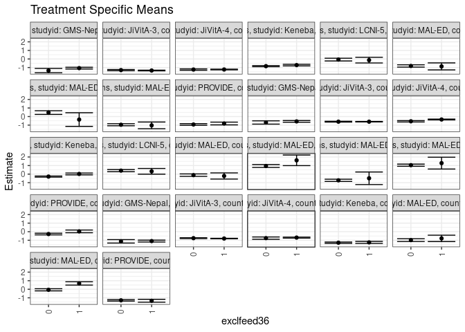

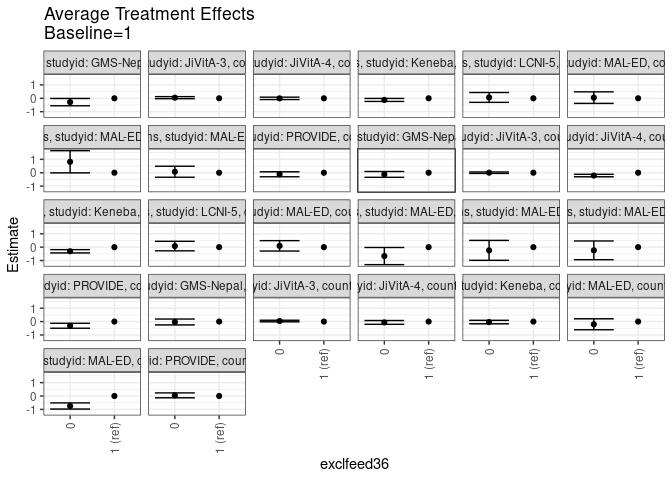

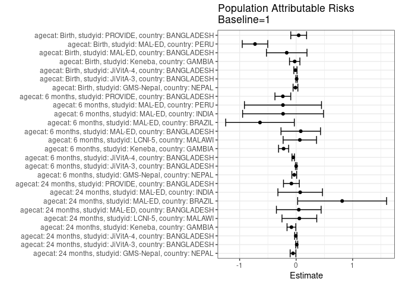

## Results Table

### Parameter: TSM

| agecat | studyid | country | intervention_level | baseline_level | estimate | ci_lower | ci_upper |
| --- | --- | --- | --- | --- | --- | --- | --- |
| Birth | GMS-Nepal | NEPAL | 1 | NA | -1.0970992 | -1.2063489 | -0.9878494 |
| Birth | GMS-Nepal | NEPAL | 0 | NA | -1.1271168 | -1.3277227 | -0.9265110 |
| Birth | JiVitA-3 | BANGLADESH | 1 | NA | -0.7984811 | -0.8255344 | -0.7714277 |
| Birth | JiVitA-3 | BANGLADESH | 0 | NA | -0.7558619 | -0.8080761 | -0.7036478 |
| Birth | JiVitA-4 | BANGLADESH | 1 | NA | -0.6894941 | -0.7454503 | -0.6335378 |
| Birth | JiVitA-4 | BANGLADESH | 0 | NA | -0.7518178 | -0.8853678 | -0.6182677 |
| Birth | Keneba | GAMBIA | 1 | NA | -1.2498501 | -1.3660259 | -1.1336744 |
| Birth | Keneba | GAMBIA | 0 | NA | -1.2858424 | -1.3634526 | -1.2082321 |
| Birth | MAL-ED | BANGLADESH | 1 | NA | -0.7816359 | -1.1554075 | -0.4078643 |
| Birth | MAL-ED | BANGLADESH | 0 | NA | -0.9832603 | -1.1473601 | -0.8191604 |
| Birth | MAL-ED | PERU | 1 | NA | 0.6820000 | 0.4886003 | 0.8753997 |
| Birth | MAL-ED | PERU | 0 | NA | -0.0629108 | -0.1888962 | 0.0630746 |
| Birth | PROVIDE | BANGLADESH | 1 | NA | -1.3421248 | -1.5101995 | -1.1740501 |
| Birth | PROVIDE | BANGLADESH | 0 | NA | -1.2916112 | -1.3795883 | -1.2036341 |
| 6 months | GMS-Nepal | NEPAL | 1 | NA | -0.5671387 | -0.6678739 | -0.4664035 |
| 6 months | GMS-Nepal | NEPAL | 0 | NA | -0.6918580 | -0.8819741 | -0.5017419 |
| 6 months | JiVitA-3 | BANGLADESH | 1 | NA | -0.6002756 | -0.6294973 | -0.5710540 |
| 6 months | JiVitA-3 | BANGLADESH | 0 | NA | -0.5984188 | -0.6472632 | -0.5495744 |
| 6 months | JiVitA-4 | BANGLADESH | 1 | NA | -0.3444684 | -0.3900807 | -0.2988561 |
| 6 months | JiVitA-4 | BANGLADESH | 0 | NA | -0.5546325 | -0.6365582 | -0.4727068 |
| 6 months | Keneba | GAMBIA | 1 | NA | 0.0208256 | -0.0856982 | 0.1273494 |
| 6 months | Keneba | GAMBIA | 0 | NA | -0.2871368 | -0.3506022 | -0.2236714 |
| 6 months | LCNI-5 | MALAWI | 1 | NA | 0.3268155 | -0.0057339 | 0.6593649 |
| 6 months | LCNI-5 | MALAWI | 0 | NA | 0.4067087 | 0.2796853 | 0.5337320 |
| 6 months | MAL-ED | BANGLADESH | 1 | NA | -0.2176356 | -0.5781707 | 0.1428995 |
| 6 months | MAL-ED | BANGLADESH | 0 | NA | -0.1193874 | -0.2621249 | 0.0233502 |
| 6 months | MAL-ED | BRAZIL | 1 | NA | 1.6117576 | 0.9940320 | 2.2294832 |
| 6 months | MAL-ED | BRAZIL | 0 | NA | 0.9465644 | 0.7771876 | 1.1159412 |
| 6 months | MAL-ED | INDIA | 1 | NA | -0.4850000 | -1.2185777 | 0.2485777 |
| 6 months | MAL-ED | INDIA | 0 | NA | -0.7254799 | -0.8547181 | -0.5962418 |
| 6 months | MAL-ED | PERU | 1 | NA | 1.2841667 | 0.5956438 | 1.9726896 |
| 6 months | MAL-ED | PERU | 0 | NA | 1.0459085 | 0.9221243 | 1.1696927 |
| 6 months | PROVIDE | BANGLADESH | 1 | NA | 0.0358653 | -0.1219498 | 0.1936805 |
| 6 months | PROVIDE | BANGLADESH | 0 | NA | -0.2759672 | -0.3715610 | -0.1803733 |
| 24 months | GMS-Nepal | NEPAL | 1 | NA | -1.0685890 | -1.1673624 | -0.9698155 |
| 24 months | GMS-Nepal | NEPAL | 0 | NA | -1.3536002 | -1.6067702 | -1.1004303 |
| 24 months | JiVitA-3 | BANGLADESH | 1 | NA | -1.3459698 | -1.3846098 | -1.3073298 |
| 24 months | JiVitA-3 | BANGLADESH | 0 | NA | -1.2998554 | -1.3666924 | -1.2330183 |
| 24 months | JiVitA-4 | BANGLADESH | 1 | NA | -1.2290972 | -1.2710011 | -1.1871932 |
| 24 months | JiVitA-4 | BANGLADESH | 0 | NA | -1.2344359 | -1.3141847 | -1.1546870 |
| 24 months | Keneba | GAMBIA | 1 | NA | -0.7143126 | -0.8080661 | -0.6205591 |
| 24 months | Keneba | GAMBIA | 0 | NA | -0.8374805 | -0.8998079 | -0.7751530 |
| 24 months | LCNI-5 | MALAWI | 1 | NA | -0.1346917 | -0.4647945 | 0.1954111 |
| 24 months | LCNI-5 | MALAWI | 0 | NA | -0.0699329 | -0.2302889 | 0.0904231 |
| 24 months | MAL-ED | BANGLADESH | 1 | NA | -0.8662925 | -1.2761151 | -0.4564699 |
| 24 months | MAL-ED | BANGLADESH | 0 | NA | -0.8155991 | -0.9489100 | -0.6822882 |
| 24 months | MAL-ED | BRAZIL | 1 | NA | -0.3519834 | -1.1485367 | 0.4445699 |
| 24 months | MAL-ED | BRAZIL | 0 | NA | 0.4642935 | 0.2501582 | 0.6784288 |
| 24 months | MAL-ED | INDIA | 1 | NA | -1.0300000 | -1.4230980 | -0.6369020 |
| 24 months | MAL-ED | INDIA | 0 | NA | -0.9551163 | -1.0754326 | -0.8348000 |
| 24 months | PROVIDE | BANGLADESH | 1 | NA | -0.8108809 | -0.9716460 | -0.6501158 |
| 24 months | PROVIDE | BANGLADESH | 0 | NA | -0.9272418 | -1.0224947 | -0.8319889 |

### Parameter: E(Y)

| agecat | studyid | country | intervention_level | baseline_level | estimate | ci_lower | ci_upper |
| --- | --- | --- | --- | --- | --- | --- | --- |
| Birth | GMS-Nepal | NEPAL | NA | NA | -1.1085743 | -1.2077878 | -1.0093609 |
| Birth | JiVitA-3 | BANGLADESH | NA | NA | -0.7892308 | -0.8133344 | -0.7651272 |
| Birth | JiVitA-4 | BANGLADESH | NA | NA | -0.7018985 | -0.7560164 | -0.6477806 |
| Birth | Keneba | GAMBIA | NA | NA | -1.2752643 | -1.3442810 | -1.2062476 |
| Birth | MAL-ED | BANGLADESH | NA | NA | -0.9480769 | -1.0934921 | -0.8026617 |
| Birth | MAL-ED | PERU | NA | NA | -0.0458257 | -0.1696487 | 0.0779973 |
| Birth | PROVIDE | BANGLADESH | NA | NA | -1.2966874 | -1.3774293 | -1.2159454 |
| 6 months | GMS-Nepal | NEPAL | NA | NA | -0.6001075 | -0.6890924 | -0.5111227 |
| 6 months | JiVitA-3 | BANGLADESH | NA | NA | -0.5995202 | -0.6251579 | -0.5738825 |
| 6 months | JiVitA-4 | BANGLADESH | NA | NA | -0.3960017 | -0.4356255 | -0.3563778 |
| 6 months | Keneba | GAMBIA | NA | NA | -0.2009461 | -0.2562412 | -0.1456509 |
| 6 months | LCNI-5 | MALAWI | NA | NA | 0.3925000 | 0.2735307 | 0.5114693 |
| 6 months | MAL-ED | BANGLADESH | NA | NA | -0.1354583 | -0.2647102 | -0.0062065 |
| 6 months | MAL-ED | BRAZIL | NA | NA | 0.9720774 | 0.8078144 | 1.1363403 |
| 6 months | MAL-ED | INDIA | NA | NA | -0.7161910 | -0.8437667 | -0.5886153 |
| 6 months | MAL-ED | PERU | NA | NA | 1.0511642 | 0.9291821 | 1.1731463 |
| 6 months | PROVIDE | BANGLADESH | NA | NA | -0.1990907 | -0.2817968 | -0.1163845 |
| 24 months | GMS-Nepal | NEPAL | NA | NA | -1.1236255 | -1.2167712 | -1.0304797 |
| 24 months | JiVitA-3 | BANGLADESH | NA | NA | -1.3352235 | -1.3688736 | -1.3015735 |
| 24 months | JiVitA-4 | BANGLADESH | NA | NA | -1.2344089 | -1.2708428 | -1.1979750 |
| 24 months | Keneba | GAMBIA | NA | NA | -0.7973955 | -0.8498696 | -0.7449213 |
| 24 months | LCNI-5 | MALAWI | NA | NA | -0.0770652 | -0.2204213 | 0.0662909 |
| 24 months | MAL-ED | BANGLADESH | NA | NA | -0.8192925 | -0.9412667 | -0.6973182 |
| 24 months | MAL-ED | BRAZIL | NA | NA | 0.4626233 | 0.2567495 | 0.6684971 |
| 24 months | MAL-ED | INDIA | NA | NA | -0.9581250 | -1.0746982 | -0.8415518 |
| 24 months | PROVIDE | BANGLADESH | NA | NA | -0.8945581 | -0.9774087 | -0.8117074 |

### Parameter: ATE

| agecat | studyid | country | intervention_level | baseline_level | estimate | ci_lower | ci_upper |
| --- | --- | --- | --- | --- | --- | --- | --- |
| Birth | GMS-Nepal | NEPAL | 1 | 1 | 0.0000000 | 0.0000000 | 0.0000000 |
| Birth | GMS-Nepal | NEPAL | 0 | 1 | -0.0300177 | -0.2498965 | 0.1898611 |
| Birth | JiVitA-3 | BANGLADESH | 1 | 1 | 0.0000000 | 0.0000000 | 0.0000000 |
| Birth | JiVitA-3 | BANGLADESH | 0 | 1 | 0.0426191 | -0.0159234 | 0.1011617 |
| Birth | JiVitA-4 | BANGLADESH | 1 | 1 | 0.0000000 | 0.0000000 | 0.0000000 |
| Birth | JiVitA-4 | BANGLADESH | 0 | 1 | -0.0623237 | -0.2029263 | 0.0782789 |
| Birth | Keneba | GAMBIA | 1 | 1 | 0.0000000 | 0.0000000 | 0.0000000 |
| Birth | Keneba | GAMBIA | 0 | 1 | -0.0359922 | -0.1650162 | 0.0930318 |
| Birth | MAL-ED | BANGLADESH | 1 | 1 | 0.0000000 | 0.0000000 | 0.0000000 |
| Birth | MAL-ED | BANGLADESH | 0 | 1 | -0.2016244 | -0.6115317 | 0.2082829 |
| Birth | MAL-ED | PERU | 1 | 1 | 0.0000000 | 0.0000000 | 0.0000000 |
| Birth | MAL-ED | PERU | 0 | 1 | -0.7449108 | -0.9757262 | -0.5140954 |
| Birth | PROVIDE | BANGLADESH | 1 | 1 | 0.0000000 | 0.0000000 | 0.0000000 |
| Birth | PROVIDE | BANGLADESH | 0 | 1 | 0.0505136 | -0.1326265 | 0.2336537 |
| 6 months | GMS-Nepal | NEPAL | 1 | 1 | 0.0000000 | 0.0000000 | 0.0000000 |
| 6 months | GMS-Nepal | NEPAL | 0 | 1 | -0.1247193 | -0.3405563 | 0.0911177 |
| 6 months | JiVitA-3 | BANGLADESH | 1 | 1 | 0.0000000 | 0.0000000 | 0.0000000 |
| 6 months | JiVitA-3 | BANGLADESH | 0 | 1 | 0.0018568 | -0.0538047 | 0.0575183 |
| 6 months | JiVitA-4 | BANGLADESH | 1 | 1 | 0.0000000 | 0.0000000 | 0.0000000 |
| 6 months | JiVitA-4 | BANGLADESH | 0 | 1 | -0.2101641 | -0.3037317 | -0.1165964 |
| 6 months | Keneba | GAMBIA | 1 | 1 | 0.0000000 | 0.0000000 | 0.0000000 |
| 6 months | Keneba | GAMBIA | 0 | 1 | -0.3079624 | -0.4312398 | -0.1846850 |
| 6 months | LCNI-5 | MALAWI | 1 | 1 | 0.0000000 | 0.0000000 | 0.0000000 |
| 6 months | LCNI-5 | MALAWI | 0 | 1 | 0.0798931 | -0.2760862 | 0.4358725 |
| 6 months | MAL-ED | BANGLADESH | 1 | 1 | 0.0000000 | 0.0000000 | 0.0000000 |
| 6 months | MAL-ED | BANGLADESH | 0 | 1 | 0.0982483 | -0.2913243 | 0.4878208 |
| 6 months | MAL-ED | BRAZIL | 1 | 1 | 0.0000000 | 0.0000000 | 0.0000000 |
| 6 months | MAL-ED | BRAZIL | 0 | 1 | -0.6651932 | -1.3055963 | -0.0247901 |
| 6 months | MAL-ED | INDIA | 1 | 1 | 0.0000000 | 0.0000000 | 0.0000000 |
| 6 months | MAL-ED | INDIA | 0 | 1 | -0.2404799 | -0.9853549 | 0.5043950 |
| 6 months | MAL-ED | PERU | 1 | 1 | 0.0000000 | 0.0000000 | 0.0000000 |
| 6 months | MAL-ED | PERU | 0 | 1 | -0.2382581 | -0.9378196 | 0.4613034 |
| 6 months | PROVIDE | BANGLADESH | 1 | 1 | 0.0000000 | 0.0000000 | 0.0000000 |
| 6 months | PROVIDE | BANGLADESH | 0 | 1 | -0.3118325 | -0.4949623 | -0.1287027 |
| 24 months | GMS-Nepal | NEPAL | 1 | 1 | 0.0000000 | 0.0000000 | 0.0000000 |
| 24 months | GMS-Nepal | NEPAL | 0 | 1 | -0.2850113 | -0.5569483 | -0.0130743 |
| 24 months | JiVitA-3 | BANGLADESH | 1 | 1 | 0.0000000 | 0.0000000 | 0.0000000 |
| 24 months | JiVitA-3 | BANGLADESH | 0 | 1 | 0.0461145 | -0.0305409 | 0.1227699 |
| 24 months | JiVitA-4 | BANGLADESH | 1 | 1 | 0.0000000 | 0.0000000 | 0.0000000 |
| 24 months | JiVitA-4 | BANGLADESH | 0 | 1 | -0.0053387 | -0.0938889 | 0.0832114 |
| 24 months | Keneba | GAMBIA | 1 | 1 | 0.0000000 | 0.0000000 | 0.0000000 |
| 24 months | Keneba | GAMBIA | 0 | 1 | -0.1231679 | -0.2344617 | -0.0118741 |
| 24 months | LCNI-5 | MALAWI | 1 | 1 | 0.0000000 | 0.0000000 | 0.0000000 |
| 24 months | LCNI-5 | MALAWI | 0 | 1 | 0.0647588 | -0.3033685 | 0.4328861 |
| 24 months | MAL-ED | BANGLADESH | 1 | 1 | 0.0000000 | 0.0000000 | 0.0000000 |
| 24 months | MAL-ED | BANGLADESH | 0 | 1 | 0.0506934 | -0.3811124 | 0.4824991 |
| 24 months | MAL-ED | BRAZIL | 1 | 1 | 0.0000000 | 0.0000000 | 0.0000000 |
| 24 months | MAL-ED | BRAZIL | 0 | 1 | 0.8162769 | -0.0114596 | 1.6440134 |
| 24 months | MAL-ED | INDIA | 1 | 1 | 0.0000000 | 0.0000000 | 0.0000000 |
| 24 months | MAL-ED | INDIA | 0 | 1 | 0.0748837 | -0.3362149 | 0.4859823 |
| 24 months | PROVIDE | BANGLADESH | 1 | 1 | 0.0000000 | 0.0000000 | 0.0000000 |
| 24 months | PROVIDE | BANGLADESH | 0 | 1 | -0.1163609 | -0.3010918 | 0.0683700 |

### Parameter: PAR

| agecat | studyid | country | intervention_level | baseline_level | estimate | ci_lower | ci_upper |
| --- | --- | --- | --- | --- | --- | --- | --- |
| Birth | GMS-Nepal | NEPAL | 1 | NA | -0.0114752 | -0.0537900 | 0.0308397 |
| Birth | JiVitA-3 | BANGLADESH | 1 | NA | 0.0092503 | -0.0035580 | 0.0220586 |
| Birth | JiVitA-4 | BANGLADESH | 1 | NA | -0.0124044 | -0.0403488 | 0.0155400 |
| Birth | Keneba | GAMBIA | 1 | NA | -0.0254141 | -0.1173101 | 0.0664818 |
| Birth | MAL-ED | BANGLADESH | 1 | NA | -0.1664410 | -0.5249190 | 0.1920369 |
| Birth | MAL-ED | PERU | 1 | NA | -0.7278257 | -0.9533592 | -0.5022921 |
| Birth | PROVIDE | BANGLADESH | 1 | NA | 0.0454374 | -0.0945517 | 0.1854265 |
| 6 months | GMS-Nepal | NEPAL | 1 | NA | -0.0329688 | -0.0757518 | 0.0098142 |
| 6 months | JiVitA-3 | BANGLADESH | 1 | NA | 0.0007554 | -0.0121028 | 0.0136136 |
| 6 months | JiVitA-4 | BANGLADESH | 1 | NA | -0.0515333 | -0.0733472 | -0.0297194 |
| 6 months | Keneba | GAMBIA | 1 | NA | -0.2217717 | -0.3109411 | -0.1326023 |
| 6 months | LCNI-5 | MALAWI | 1 | NA | 0.0656845 | -0.2298623 | 0.3612312 |
| 6 months | MAL-ED | BANGLADESH | 1 | NA | 0.0821773 | -0.2677440 | 0.4320985 |
| 6 months | MAL-ED | BRAZIL | 1 | NA | -0.6396803 | -1.2471787 | -0.0321818 |
| 6 months | MAL-ED | INDIA | 1 | NA | -0.2311910 | -0.9473188 | 0.4849368 |
| 6 months | MAL-ED | PERU | 1 | NA | -0.2330025 | -0.9150876 | 0.4490827 |
| 6 months | PROVIDE | BANGLADESH | 1 | NA | -0.2349560 | -0.3750010 | -0.0949110 |
| 24 months | GMS-Nepal | NEPAL | 1 | NA | -0.0550365 | -0.1058401 | -0.0042329 |
| 24 months | JiVitA-3 | BANGLADESH | 1 | NA | 0.0107463 | -0.0070193 | 0.0285118 |
| 24 months | JiVitA-4 | BANGLADESH | 1 | NA | -0.0053118 | -0.0253362 | 0.0147127 |
| 24 months | Keneba | GAMBIA | 1 | NA | -0.0830829 | -0.1608321 | -0.0053336 |
| 24 months | LCNI-5 | MALAWI | 1 | NA | 0.0576265 | -0.2500888 | 0.3653418 |
| 24 months | MAL-ED | BANGLADESH | 1 | NA | 0.0470000 | -0.3489961 | 0.4429961 |
| 24 months | MAL-ED | BRAZIL | 1 | NA | 0.8146067 | 0.0272150 | 1.6019983 |
| 24 months | MAL-ED | INDIA | 1 | NA | 0.0718750 | -0.3227110 | 0.4664610 |
| 24 months | PROVIDE | BANGLADESH | 1 | NA | -0.0836772 | -0.2236347 | 0.0562804 |